# Final_Report_Complete

### EDA_enriched_API.ipynb — Code Cell 13

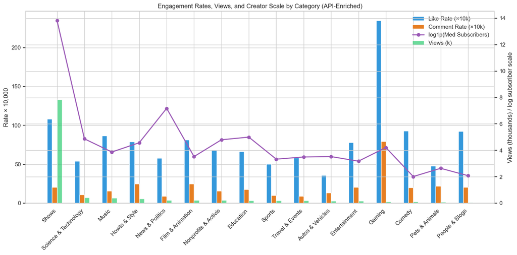

| category | Avg Like Rate | Med Like Rate | Avg Comment Rate | Med Comment Rate | Avg Views | Med Views | Avg Engagement | Med Engagement | Med Subscribers | yt_subscriber_count_mean | Med Uploads | yt_channel_video_count_mean | Med Channel Views | yt_channel_view_count_mean | Med Video Length (sec) | yt_duration_sec_mean | Med Video Age (days) | video_age_days_mean | Med Channel Age (days) | channel_age_days_mean | Avg Thumb Brightness | thumb_mean_brightness_median | Avg Thumb Colorfulness | thumb_colorfulness_median |
| --- | --- | --- | --- | --- | --- | --- | --- | --- | --- | --- | --- | --- | --- | --- | --- | --- | --- | --- | --- | --- | --- | --- | --- | --- |
| Shows | 0.010817 | 0.007162 | 0.002048 | 0.0005 | 226126.777778 | 7854.5 | 4.421813 | 4.094345 | 1016500.0 | 1.299457e+07 | 7997.0 | 44341.277778 | 540121730.5 | 1.283870e+10 | 571.0 | 714.500000 | 4768.0 | 4734.722222 | 5872.0 | 5945.777778 | 86.265783 | 82.447845 | 58.345849 | 46.658305 |
| Science & Technology | 0.005399 | 0.001695 | 0.001122 | 0.0000 | 12480.841727 | 427.0 | 1.461065 | 1.098612 | 129.5 | 2.335962e+05 | 62.5 | 1536.507194 | 87959.0 | 6.114629e+07 | 143.0 | 333.093525 | 4929.0 | 5067.201439 | 5617.0 | 5639.230216 | 103.938039 | 103.115082 | 41.125442 | 37.905294 |
| Music | 0.008680 | 0.004556 | 0.001555 | 0.0000 | 126966.233978 | 392.0 | 1.893343 | 1.386294 | 47.0 | 1.828614e+04 | 30.0 | 739.614106 | 43273.0 | 1.295446e+07 | 210.0 | 260.937267 | 5198.0 | 5288.727026 | 5919.0 | 5897.364869 | 74.708329 | 72.352005 | 42.520651 | 38.061788 |
| Howto & Style | 0.007894 | 0.001652 | 0.002504 | 0.0000 | 27299.501475 | 342.0 | 1.774540 | 1.098612 | 96.0 | 4.531262e+04 | 48.0 | 1578.188791 | 63826.0 | 1.416841e+07 | 144.0 | 216.781711 | 4997.0 | 5129.935103 | 5574.0 | 5665.200590 | 104.260060 | 103.420830 | 44.339189 | 40.711170 |
| News & Politics | 0.005781 | 0.001142 | 0.000924 | 0.0000 | 29510.155803 | 229.0 | 1.211044 | 0.693147 | 1310.0 | 5.596005e+05 | 770.5 | 25449.038462 | 1057701.0 | 4.132641e+08 | 147.0 | 279.871224 | 4980.0 | 5094.915739 | 5812.5 | 5783.724359 | 94.521343 | 94.794754 | 42.503374 | 39.219580 |
| Film & Animation | 0.008149 | 0.002480 | 0.002505 | 0.0000 | 40054.389744 | 226.0 | 1.615276 | 1.098612 | 33.0 | 4.271621e+04 | 26.0 | 667.938462 | 27478.0 | 2.056075e+07 | 113.0 | 223.690598 | 5167.0 | 5294.553846 | 5753.0 | 5803.461538 | 92.637501 | 90.308975 | 39.107077 | 35.780662 |
| Nonprofits & Activis | 0.006780 | 0.002869 | 0.001594 | 0.0000 | 5854.972973 | 220.5 | 1.213630 | 0.693147 | 120.5 | 2.708069e+04 | 61.0 | 1499.576577 | 53536.0 | 1.112945e+07 | 225.0 | 545.977578 | 5042.0 | 5101.430493 | 5748.5 | 5786.590090 | 96.305628 | 95.192429 | 41.251199 | 37.393499 |
| Education | 0.006668 | 0.001901 | 0.001751 | 0.0000 | 672632.485086 | 199.0 | 1.302287 | 0.693147 | 147.5 | 3.859856e+04 | 70.5 | 2570.474922 | 83654.0 | 2.556014e+07 | 204.5 | 432.840125 | 4979.0 | 5097.579937 | 5560.0 | 5641.612853 | 104.329003 | 100.789787 | 39.991250 | 34.980106 |
| Sports | 0.005006 | 0.000284 | 0.001008 | 0.0000 | 8704.703673 | 193.0 | 1.004425 | 0.693147 | 27.0 | 3.267978e+04 | 59.0 | 3345.985294 | 29927.5 | 1.579534e+07 | 97.0 | 219.551837 | 5146.0 | 5250.332245 | 5915.0 | 5893.804739 | 105.409235 | 107.782963 | 40.280916 | 36.443412 |
| Travel & Events | 0.005864 | 0.000000 | 0.000919 | 0.0000 | 11762.146758 | 183.5 | 0.867341 | 0.000000 | 32.0 | 3.601897e+04 | 45.0 | 1107.255973 | 36305.5 | 2.563413e+07 | 106.0 | 189.631399 | 5251.0 | 5339.604096 | 6063.0 | 5996.569966 | 97.629303 | 101.728256 | 39.752929 | 34.847926 |
| Autos & Vehicles | 0.003614 | 0.000000 | 0.001352 | 0.0000 | 23282.590452 | 170.5 | 1.059763 | 0.000000 | 33.0 | 1.970571e+04 | 128.5 | 3603.713568 | 51376.0 | 8.453532e+06 | 67.5 | 138.585427 | 5036.5 | 5163.575377 | 5674.0 | 5755.796482 | 100.278714 | 101.979488 | 33.442601 | 29.590767 |
| Entertainment | 0.007787 | 0.001506 | 0.002075 | 0.0000 | 32572.067471 | 160.5 | 1.217904 | 0.693147 | 23.0 | 1.461291e+05 | 30.0 | 1672.485727 | 15678.5 | 9.506764e+07 | 110.0 | 198.759144 | 5151.0 | 5290.246655 | 5869.5 | 5866.352364 | 87.202469 | 87.910343 | 42.475797 | 38.258154 |

```python
def pick_col(primary, fallback):
    return primary if primary in df_eng.columns else fallback

views_col    = pick_col("yt_view_count", "views")
likes_col    = pick_col("yt_like_count", "likes")
comments_col = pick_col("yt_comment_count", "comments")


for c in [views_col, likes_col, comments_col,
          "yt_subscriber_count", "yt_channel_video_count", "yt_channel_view_count",
          "yt_duration_sec", "thumb_mean_brightness", "thumb_colorfulness",
          "video_age_days", "channel_age_days",
          "like_rate", "comment_rate", "engagement_score"]:
    if c in df_eng.columns:
        df_eng[c] = pd.to_numeric(df_eng[c], errors="coerce")


agg_dict = {
    "like_rate": ["mean", "median"],
    "comment_rate": ["mean", "median"],
    views_col: ["mean", "median"],
    "engagement_score": ["mean", "median"],
}


optional_vars = {
    "yt_subscriber_count": ["median", "mean"],
    "yt_channel_video_count": ["median", "mean"],
    "yt_channel_view_count": ["median", "mean"],
    "yt_duration_sec": ["median", "mean"],
    "video_age_days": ["median", "mean"],
    "channel_age_days": ["median", "mean"],
    "thumb_mean_brightness": ["mean", "median"],
    "thumb_colorfulness": ["mean", "median"],
}

for col, funcs in optional_vars.items():
    if col in df_eng.columns:
        agg_dict[col] = funcs

rate_by_cat = df_eng.groupby("category").agg(agg_dict)


rate_by_cat.columns = ["_".join([str(c) for c in tup if c]) for tup in rate_by_cat.columns]
rate_by_cat = rate_by_cat.reset_index()


rename_map = {
    "like_rate_mean": "Avg Like Rate",
    "comment_rate_mean": "Avg Comment Rate",
    f"{views_col}_mean": "Avg Views",
    "engagement_score_mean": "Avg Engagement",

    "like_rate_median": "Med Like Rate",
    "comment_rate_median": "Med Comment Rate",
    f"{views_col}_median": "Med Views",
    "engagement_score_median": "Med Engagement",

    "yt_subscriber_count_median": "Med Subscribers",
    "yt_channel_video_count_median": "Med Uploads",
    "yt_channel_view_count_median": "Med Channel Views",
    "yt_duration_sec_median": "Med Video Length (sec)",
    "video_age_days_median": "Med Video Age (days)",
    "channel_age_days_median": "Med Channel Age (days)",
    "thumb_mean_brightness_mean": "Avg Thumb Brightness",
    "thumb_colorfulness_mean": "Avg Thumb Colorfulness",
}
rate_by_cat = rate_by_cat.rename(columns={k: v for k, v in rename_map.items() if k in rate_by_cat.columns})


sort_col = "Med Views" if "Med Views" in rate_by_cat.columns else "Avg Views"
rate_by_cat = rate_by_cat.sort_values(sort_col, ascending=False).set_index("category")


fig, ax = plt.subplots(figsize=(14, 7))
x = np.arange(len(rate_by_cat))
w = 0.18


like_rate_plot = rate_by_cat["Avg Like Rate"] if "Avg Like Rate" in rate_by_cat.columns else rate_by_cat["Med Like Rate"]
com_rate_plot  = rate_by_cat["Avg Comment Rate"] if "Avg Comment Rate" in rate_by_cat.columns else rate_by_cat["Med Comment Rate"]
views_plot     = rate_by_cat["Med Views"] if "Med Views" in rate_by_cat.columns else rate_by_cat["Avg Views"]

ax.bar(x - 1.5*w, like_rate_plot * 10000, width=w, label="Like Rate (×10k)", color="#3498db")
ax.bar(x - 0.5*w, com_rate_plot  * 10000, width=w, label="Comment Rate (×10k)", color="#e67e22")


ax2 = ax.twinx()
ax2.bar(x + 0.5*w, views_plot / 1000, width=w, label="Views (k)", color="#2ecc71", alpha=0.7)


if "Med Subscribers" in rate_by_cat.columns:

    subs_scaled = np.log1p(rate_by_cat["Med Subscribers"])
    ax2.plot(x, subs_scaled, marker="o", linewidth=2, label="log1p(Med Subscribers)", color="#9b59b6")

ax.set_xticks(x)
ax.set_xticklabels(rate_by_cat.index, rotation=45, ha="right")
ax.set_ylabel("Rate × 10,000")
ax2.set_ylabel("Views (thousands) / log subscriber scale")


lines1, labels1 = ax.get_legend_handles_labels()
lines2, labels2 = ax2.get_legend_handles_labels()
ax.legend(lines1 + lines2, labels1 + labels2, loc="upper right")

ax.set_title("Engagement Rates, Views, and Creator Scale by Category (API-Enriched)")
plt.tight_layout()
plt.show()


display(rate_by_cat.head(12))
```

### EDA_enriched_API.ipynb — Code Cell 14

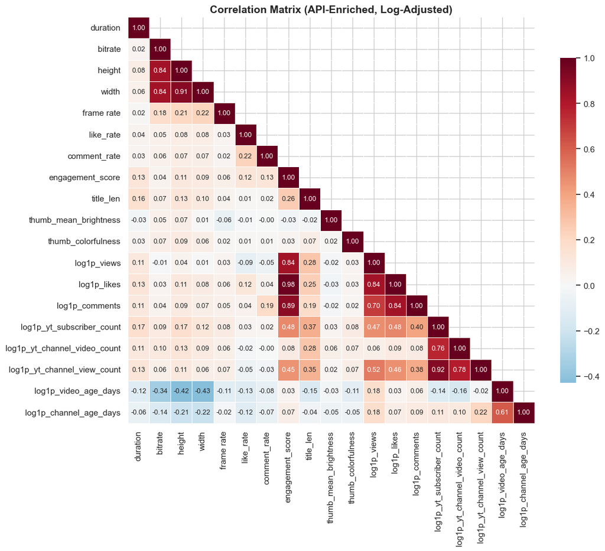

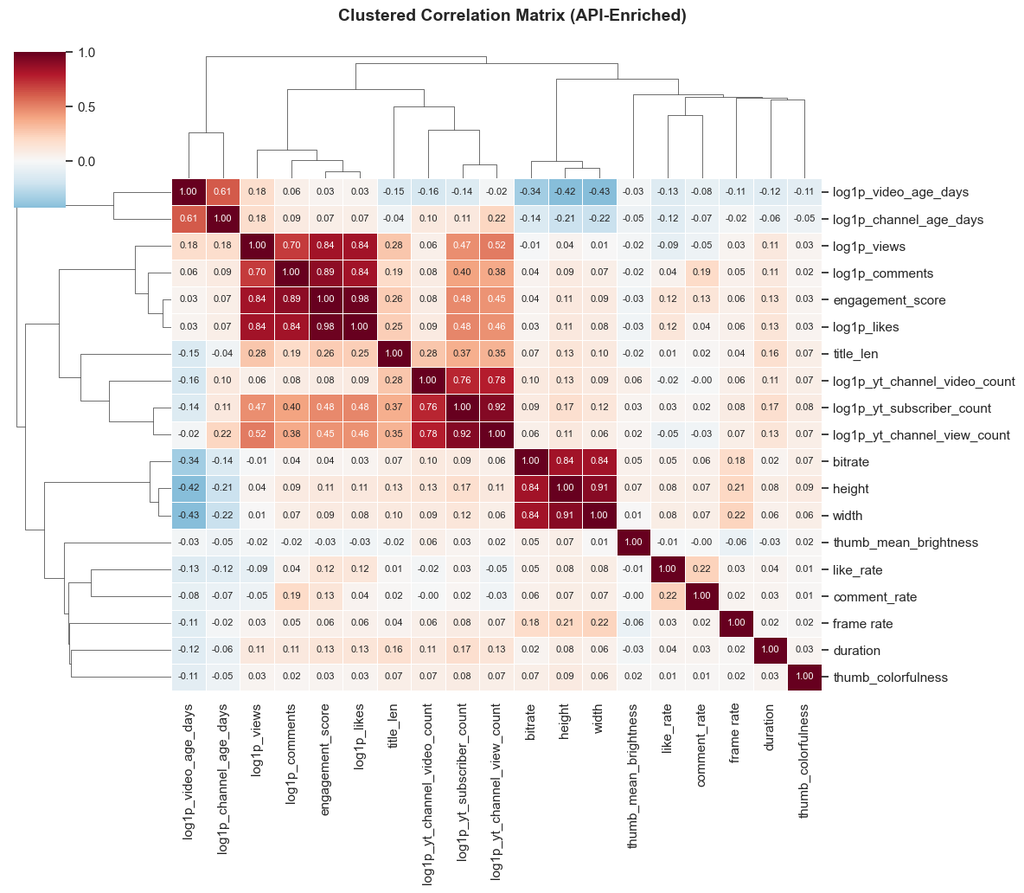

```python
corr_cols = [

    "duration",
    "bitrate",
    "height",
    "width",
    "frame rate",


    "views",
    "likes",
    "comments",
    "like_rate",
    "comment_rate",
    "engagement_score",


    "yt_subscriber_count",
    "yt_channel_video_count",
    "yt_channel_view_count",


    "video_age_days",
    "channel_age_days",


    "title_len",
    "hashtag_count",


    "thumb_mean_brightness",
    "thumb_colorfulness",
]


corr_cols = [c for c in corr_cols if c in df_eng.columns]


corr_df = df_eng[corr_cols].copy()


corr_df = corr_df.apply(pd.to_numeric, errors="coerce")


log_cols = [
    "views", "likes", "comments",
    "yt_subscriber_count", "yt_channel_video_count", "yt_channel_view_count",
    "video_age_days", "channel_age_days"
]

for col in log_cols:
    if col in corr_df.columns:
        corr_df[f"log1p_{col}"] = np.log1p(corr_df[col])


final_corr_cols = [
    c for c in corr_df.columns
    if not (c in log_cols)
]

corr_df = corr_df[final_corr_cols].dropna()


corr_matrix = corr_df.corr()


fig, ax = plt.subplots(figsize=(12, 10))
mask = np.triu(np.ones_like(corr_matrix, dtype=bool), k=1)

sns.heatmap(
    corr_matrix,
    mask=mask,
    annot=True,
    fmt=".2f",
    cmap="RdBu_r",
    center=0,
    square=True,
    linewidths=0.5,
    cbar_kws={"shrink": 0.8},
    annot_kws={"size": 9},
    ax=ax
)

ax.set_title("Correlation Matrix (API-Enriched, Log-Adjusted)", fontsize=14, fontweight="bold")
plt.tight_layout()
plt.show()


g = sns.clustermap(
    corr_matrix,
    annot=True,
    fmt=".2f",
    cmap="RdBu_r",
    center=0,
    figsize=(12, 10),
    linewidths=0.5,
    annot_kws={"size": 8}
)

g.fig.suptitle("Clustered Correlation Matrix (API-Enriched)", y=1.03, fontsize=14, fontweight="bold")
plt.show()
```

### EDA_enriched_API.ipynb — Code Cell 15

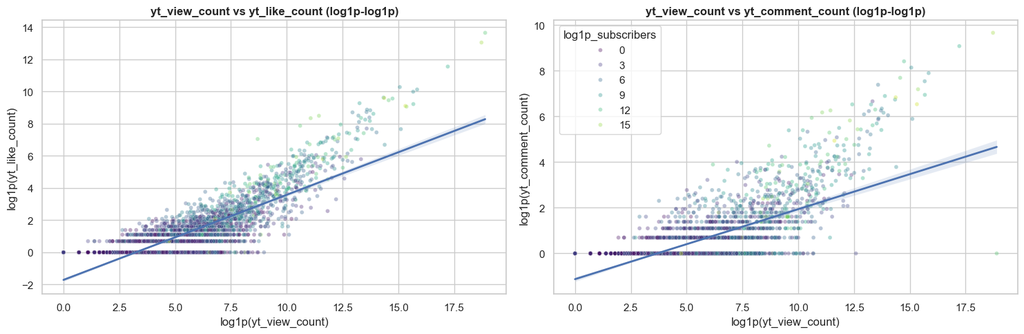

```python
sns.set(style="whitegrid")


base = df_eng if "df_eng" in globals() else df


views_col    = "yt_view_count"    if "yt_view_count"    in base.columns else "views"
likes_col    = "yt_like_count"    if "yt_like_count"    in base.columns else "likes"
comments_col = "yt_comment_count" if "yt_comment_count" in base.columns else "comments"


hue_col = None
if "log1p_subscribers" in base.columns:
    hue_col = "log1p_subscribers"
elif "yt_subscriber_count" in base.columns:
    base = base.copy()
    base["log1p_subscribers"] = np.log1p(pd.to_numeric(base["yt_subscriber_count"], errors="coerce"))
    hue_col = "log1p_subscribers"


sample = base.sample(min(4000, len(base)), random_state=42).copy()


for c in [views_col, likes_col, comments_col]:
    sample[c] = pd.to_numeric(sample[c], errors="coerce")

sample = sample.dropna(subset=[views_col, likes_col, comments_col])

sample["log1p_views"]    = np.log1p(sample[views_col])
sample["log1p_likes"]    = np.log1p(sample[likes_col])
sample["log1p_comments"] = np.log1p(sample[comments_col])


fig, axes = plt.subplots(1, 2, figsize=(15, 5))


sns.scatterplot(
    data=sample,
    x="log1p_views",
    y="log1p_likes",
    hue=hue_col,
    palette="viridis" if hue_col else None,
    alpha=0.35,
    s=18,
    ax=axes[0],
    legend=False
)

sns.regplot(
    data=sample,
    x="log1p_views",
    y="log1p_likes",
    scatter=False,
    ax=axes[0],
    line_kws={"lw": 2}
)

axes[0].set_title(f"{views_col} vs {likes_col} (log1p-log1p)", fontweight="bold")
axes[0].set_xlabel(f"log1p({views_col})")
axes[0].set_ylabel(f"log1p({likes_col})")


sns.scatterplot(
    data=sample,
    x="log1p_views",
    y="log1p_comments",
    hue=hue_col,
    palette="viridis" if hue_col else None,
    alpha=0.35,
    s=18,
    ax=axes[1],
    legend=True if hue_col else False
)

sns.regplot(
    data=sample,
    x="log1p_views",
    y="log1p_comments",
    scatter=False,
    ax=axes[1],
    line_kws={"lw": 2}
)

axes[1].set_title(f"{views_col} vs {comments_col} (log1p-log1p)", fontweight="bold")
axes[1].set_xlabel(f"log1p({views_col})")
axes[1].set_ylabel(f"log1p({comments_col})")


if hue_col:
    axes[1].legend(title=hue_col, loc="best", frameon=True)

plt.tight_layout()
plt.show()
```

### EDA_enriched_API.ipynb — Code Cell 16

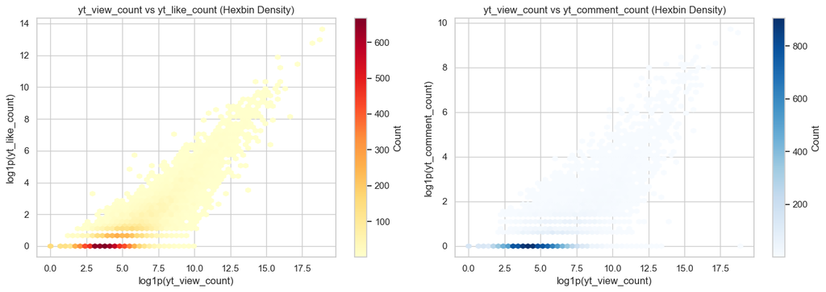

```python
base = df_eng if "df_eng" in globals() else df


views_col    = "yt_view_count"    if "yt_view_count"    in base.columns else "views"
likes_col    = "yt_like_count"    if "yt_like_count"    in base.columns else "likes"
comments_col = "yt_comment_count" if "yt_comment_count" in base.columns else "comments"


plot_df = base[[views_col, likes_col, comments_col]].copy()
for c in [views_col, likes_col, comments_col]:
    plot_df[c] = pd.to_numeric(plot_df[c], errors="coerce")

plot_df = plot_df.dropna(subset=[views_col, likes_col, comments_col])


x = np.log1p(plot_df[views_col].clip(lower=0))
y_likes = np.log1p(plot_df[likes_col].clip(lower=0))
y_comments = np.log1p(plot_df[comments_col].clip(lower=0))


fig, axes = plt.subplots(1, 2, figsize=(14, 5))

h1 = axes[0].hexbin(x, y_likes, gridsize=55, cmap="YlOrRd", mincnt=1)
plt.colorbar(h1, ax=axes[0], label="Count")
axes[0].set_xlabel(f"log1p({views_col})")
axes[0].set_ylabel(f"log1p({likes_col})")
axes[0].set_title(f"{views_col} vs {likes_col} (Hexbin Density)")

h2 = axes[1].hexbin(x, y_comments, gridsize=55, cmap="Blues", mincnt=1)
plt.colorbar(h2, ax=axes[1], label="Count")
axes[1].set_xlabel(f"log1p({views_col})")
axes[1].set_ylabel(f"log1p({comments_col})")
axes[1].set_title(f"{views_col} vs {comments_col} (Hexbin Density)")

plt.tight_layout()
plt.show()
```

### EDA_enriched_API.ipynb — Code Cell 17

```python
def count_outliers_iqr(series):
    series = series.dropna()
    if series.empty:
        return np.nan, np.nan
    Q1, Q3 = series.quantile([0.25, 0.75])
    IQR = Q3 - Q1
    low, high = Q1 - 1.5 * IQR, Q3 + 1.5 * IQR
    outliers = ((series < low) | (series > high)).sum()
    pct = round(outliers / len(series) * 100, 2)
    return outliers, pct


base = df_eng if "df_eng" in globals() else df


views_col    = "yt_view_count"    if "yt_view_count"    in base.columns else "views"
likes_col    = "yt_like_count"    if "yt_like_count"    in base.columns else "likes"
comments_col = "yt_comment_count" if "yt_comment_count" in base.columns else "comments"


outlier_vars = {

    views_col: "Views",
    likes_col: "Likes",
    comments_col: "Comments",


    "like_rate_cap": "Like Rate (capped)",
    "comment_rate_cap": "Comment Rate (capped)",


    "log1p_subscribers": "Subscribers (log1p)",
    "log1p_channel_uploads": "Channel Uploads (log1p)",


    "video_age_days": "Video Age (days)",
    "channel_age_days": "Channel Age (days)",


    "log1p_video_len_sec": "Video Length (log1p)",
    "title_len": "Title Length",


    "thumb_mean_brightness": "Thumbnail Brightness",
    "thumb_colorfulness": "Thumbnail Colorfulness"
}


outlier_vars = {k: v for k, v in outlier_vars.items() if k in base.columns}


rows = []
for col, label in outlier_vars.items():
    outliers, pct = count_outliers_iqr(pd.to_numeric(base[col], errors="coerce"))
    rows.append({
        "Variable": label,
        "Column": col,
        "Outliers (IQR)": outliers,
        "Pct of Observations (%)": pct
    })

outlier_summary = pd.DataFrame(rows).sort_values(
    "Pct of Observations (%)", ascending=False
)

outlier_summary
```

|  | Variable | Column | Outliers (IQR) | Pct of Observations (%) |
| --- | --- | --- | --- | --- |
| 4 | Comment Rate (capped) | comment_rate_cap | 3137 | 19.61 |
| 0 | Views | yt_view_count | 2868 | 16.40 |
| 2 | Comments | yt_comment_count | 2412 | 14.93 |
| 1 | Likes | yt_like_count | 2565 | 14.85 |
| 3 | Like Rate (capped) | like_rate_cap | 1798 | 10.51 |
| 12 | Thumbnail Colorfulness | thumb_colorfulness | 563 | 3.22 |
| 10 | Title Length | title_len | 415 | 2.36 |
| 6 | Channel Uploads (log1p) | log1p_channel_uploads | 353 | 2.02 |
| 5 | Subscribers (log1p) | log1p_subscribers | 298 | 1.70 |
| 9 | Video Length (log1p) | log1p_video_len_sec | 168 | 0.96 |
| 11 | Thumbnail Brightness | thumb_mean_brightness | 146 | 0.84 |
| 7 | Video Age (days) | video_age_days | 51 | 0.29 |
| 8 | Channel Age (days) | channel_age_days | 0 | 0.00 |

### EDA_enriched_API.ipynb — Code Cell 18

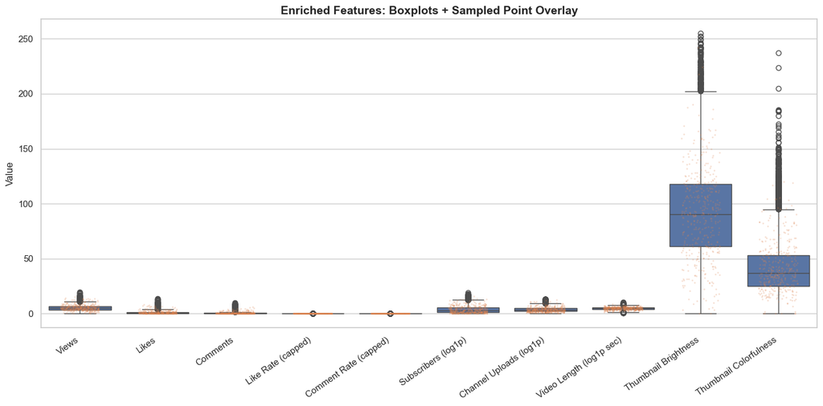

```python
sns.set(style="whitegrid")


base = df_eng if "df_eng" in globals() else df


views_col    = "yt_view_count"    if "yt_view_count"    in base.columns else "views"
likes_col    = "yt_like_count"    if "yt_like_count"    in base.columns else "likes"
comments_col = "yt_comment_count" if "yt_comment_count" in base.columns else "comments"


plot_specs = [
    (views_col, "Views", "log1p"),
    (likes_col, "Likes", "log1p"),
    (comments_col, "Comments", "log1p"),
    ("like_rate_cap", "Like Rate (capped)", "none"),
    ("comment_rate_cap", "Comment Rate (capped)", "none"),
    ("log1p_subscribers", "Subscribers (log1p)", "none"),
    ("log1p_channel_uploads", "Channel Uploads (log1p)", "none"),
    ("log1p_video_len_sec", "Video Length (log1p sec)", "none"),
    ("thumb_mean_brightness", "Thumbnail Brightness", "none"),
    ("thumb_colorfulness", "Thumbnail Colorfulness", "none"),
]


plot_specs = [(c, lab, tr) for (c, lab, tr) in plot_specs if c in base.columns]


rows = []
for col, label, tr in plot_specs:
    s = pd.to_numeric(base[col], errors="coerce")
    if tr == "log1p":
        s = np.log1p(s.clip(lower=0))
    rows.append(pd.DataFrame({"Metric": label, "Value": s}))

plot_df = pd.concat(rows, ignore_index=True).dropna(subset=["Value"])


N_STRIP = min(4000, len(plot_df))
strip_df = plot_df.sample(N_STRIP, random_state=42) if len(plot_df) > N_STRIP else plot_df


plt.figure(figsize=(14, 7))
sns.boxplot(
    data=plot_df,
    x="Metric",
    y="Value",
    showfliers=True
)

sns.stripplot(
    data=strip_df,
    x="Metric",
    y="Value",
    size=2,
    alpha=0.25,
    jitter=0.25
)

plt.title("Enriched Features: Boxplots + Sampled Point Overlay", fontsize=14, fontweight="bold")
plt.xlabel("")
plt.xticks(rotation=35, ha="right")
plt.tight_layout()
plt.show()
```

### EDA_enriched_API.ipynb — Code Cell 19

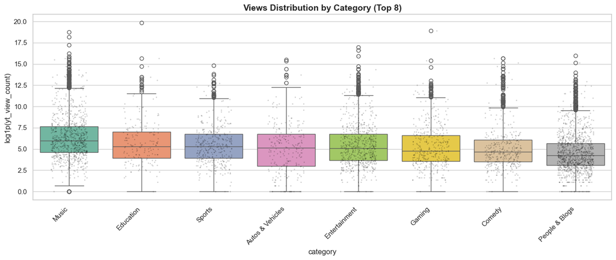

```python
sns.set(style="whitegrid")


base = df_eng if "df_eng" in globals() else df


views_col = "yt_view_count" if "yt_view_count" in base.columns else "views"


TOP_N = 8
top_categories = base["category"].value_counts().head(TOP_N).index.tolist()

df_top = base[base["category"].isin(top_categories)].copy()
df_top = df_top.dropna(subset=["category", views_col])


df_top[views_col] = pd.to_numeric(df_top[views_col], errors="coerce")
df_top["log_views"] = np.log1p(df_top[views_col].clip(lower=0))


cat_order = (
    df_top.groupby("category")["log_views"]
    .median()
    .sort_values(ascending=False)
    .index.tolist()
)


N_STRIP = min(4000, len(df_top))
df_strip = df_top.sample(N_STRIP, random_state=42) if len(df_top) > N_STRIP else df_top


plt.figure(figsize=(14, 6))

sns.boxplot(
    data=df_top,
    x="category",
    y="log_views",
    order=cat_order,
    palette="Set2",
    showfliers=True
)

sns.stripplot(
    data=df_strip,
    x="category",
    y="log_views",
    order=cat_order,
    color="black",
    alpha=0.20,
    jitter=0.25,
    size=2
)

plt.xticks(rotation=45, ha="right")
plt.ylabel(f"log1p({views_col})")
plt.title(f"Views Distribution by Category (Top {TOP_N})", fontsize=14, fontweight="bold")
plt.tight_layout()
plt.show()
```

### EDA_enriched_API.ipynb — Code Cell 20

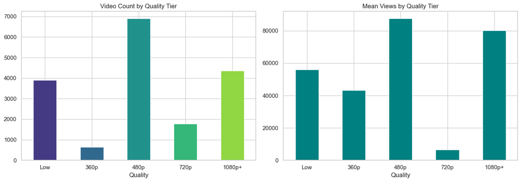

```python
df_res = df.copy()
df_res['aspect_ratio'] = df_res['width'] / (df_res['height'] + 1e-6)
df_res['pixels'] = df_res['width'] * df_res['height']

def quality_tier(row):
    w, h = row['width'], row['height']
    if w >= 1920 or h >= 1080: return '1080p+'
    if w >= 1280 or h >= 720: return '720p'
    if w >= 854 or h >= 480: return '480p'
    if w >= 640 or h >= 360: return '360p'
    return 'Low'

df_res['quality_tier'] = df_res.apply(quality_tier, axis=1)

fig, axes = plt.subplots(1, 2, figsize=(14, 5))

quality_order = ['Low', '360p', '480p', '720p', '1080p+']
qt_counts = df_res['quality_tier'].value_counts().reindex(quality_order).dropna()
if len(qt_counts) > 0:
    qt_counts.plot(kind='bar', ax=axes[0], color=sns.color_palette('viridis', len(qt_counts)))
axes[0].set_title('Video Count by Quality Tier')
axes[0].set_xlabel('Quality')
axes[0].tick_params(axis='x', rotation=0)

mean_views_qt = df_res.groupby('quality_tier')['views'].mean().reindex(quality_order).dropna()
if len(mean_views_qt) > 0:
    mean_views_qt.plot(kind='bar', ax=axes[1], color='teal')
axes[1].set_title('Mean Views by Quality Tier')
axes[1].set_xlabel('Quality')
axes[1].tick_params(axis='x', rotation=0)

plt.tight_layout()
plt.show()
```

### Figure Interpretation

This visualization shows how the selected variables relate to the target and to each other. The observed separation and shape of distributions indicate that these features contain usable predictive structure.

### EDA_enriched_API.ipynb — Code Cell 21

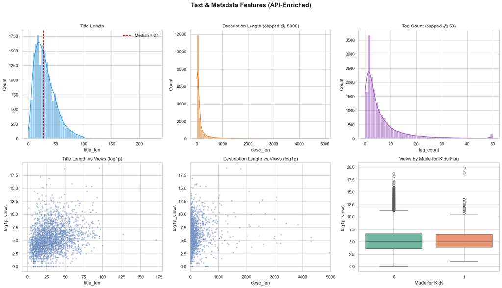

```python
import numpy as np
import pandas as pd
import seaborn as sns
import matplotlib.pyplot as plt

sns.set(style="whitegrid")

df_txt = df.copy()


title_col = "yt_title" if "yt_title" in df_txt.columns else "title"
desc_col  = "yt_description" if "yt_description" in df_txt.columns else "description"
tags_col  = "yt_tags_json" if "yt_tags_json" in df_txt.columns else "hashtags"


df_txt["title_len"] = df_txt[title_col].fillna("").astype(str).str.len()
df_txt["desc_len"]  = df_txt[desc_col].fillna("").astype(str).str.len()


def count_tags(x):
    if pd.isna(x) or str(x).strip() == "":
        return 0
    s = str(x)
    if s.startswith("["):
        return s.count(",") + 1
    return len([t for t in s.split(",") if t.strip()])

df_txt["tag_count"] = df_txt[tags_col].apply(count_tags)


if "yt_default_language" in df_txt.columns:
    df_txt["has_default_lang"] = df_txt["yt_default_language"].notna().astype(int)
else:
    df_txt["has_default_lang"] = 0

if "yt_default_audio_language" in df_txt.columns:
    df_txt["has_audio_lang"] = df_txt["yt_default_audio_language"].notna().astype(int)
else:
    df_txt["has_audio_lang"] = 0

if "yt_made_for_kids" in df_txt.columns:
    df_txt["made_for_kids"] = df_txt["yt_made_for_kids"].fillna(False).astype(int)
else:
    df_txt["made_for_kids"] = 0


views_col = "yt_view_count" if "yt_view_count" in df_txt.columns else "views"
df_txt[views_col] = pd.to_numeric(df_txt[views_col], errors="coerce")
df_txt["log1p_views"] = np.log1p(df_txt[views_col])


fig, axes = plt.subplots(2, 3, figsize=(18, 10))


sns.histplot(df_txt["title_len"], bins=60, kde=True, ax=axes[0, 0], color="#3498db")
axes[0, 0].axvline(df_txt["title_len"].median(), color="red", ls="--",
                   label=f"Median = {df_txt['title_len'].median():.0f}")
axes[0, 0].set_title("Title Length")
axes[0, 0].legend()


sns.histplot(df_txt["desc_len"].clip(upper=5000), bins=60, kde=True,
             ax=axes[0, 1], color="#e67e22")
axes[0, 1].set_title("Description Length (capped @ 5000)")


sns.histplot(df_txt["tag_count"].clip(upper=50), bins=50, kde=True,
             ax=axes[0, 2], color="#9b59b6")
axes[0, 2].set_title("Tag Count (capped @ 50)")


sample_txt = df_txt.sample(min(2500, len(df_txt)), random_state=42)

sns.scatterplot(
    data=sample_txt,
    x="title_len",
    y="log1p_views",
    alpha=0.4,
    s=14,
    ax=axes[1, 0]
)
axes[1, 0].set_title("Title Length vs Views (log1p)")

sns.scatterplot(
    data=sample_txt,
    x="desc_len",
    y="log1p_views",
    alpha=0.4,
    s=14,
    ax=axes[1, 1]
)
axes[1, 1].set_xlim(0, 5000)
axes[1, 1].set_title("Description Length vs Views (log1p)")

sns.boxplot(
    data=df_txt,
    x="made_for_kids",
    y="log1p_views",
    ax=axes[1, 2],
    palette="Set2"
)
axes[1, 2].set_title("Views by Made-for-Kids Flag")
axes[1, 2].set_xlabel("Made for Kids")

plt.suptitle("Text & Metadata Features (API-Enriched)", fontsize=16, fontweight="bold", y=1.02)
plt.tight_layout()
plt.show()
```

### Figure Interpretation

This visualization shows how the selected variables relate to the target and to each other. The observed separation and shape of distributions indicate that these features contain usable predictive structure.

### EDA_enriched_API.ipynb — Code Cell 22

```python
import numpy as np
import pandas as pd


def pick_col(primary, fallback, df_):
    return primary if primary in df_.columns else fallback

views_col    = pick_col("yt_view_count", "views", df)
likes_col    = pick_col("yt_like_count", "likes", df)
comments_col = pick_col("yt_comment_count", "comments", df)
title_col    = pick_col("yt_title", "title", df)
desc_col     = pick_col("yt_description", "description", df)
dur_col      = pick_col("yt_duration_sec", "duration", df)


df_sum = df.copy()

num_cols = [
    views_col, likes_col, comments_col,
    dur_col, "bitrate", "width", "height", "frame rate", "frame_rate",
    "yt_subscriber_count", "yt_channel_video_count", "yt_channel_view_count",
    "thumb_mean_brightness", "thumb_colorfulness"
]
for c in num_cols:
    if c in df_sum.columns:
        df_sum[c] = pd.to_numeric(df_sum[c], errors="coerce")


df_sum["like_rate"] = df_sum[likes_col] / df_sum[views_col].replace(0, np.nan)
df_sum["comment_rate"] = df_sum[comments_col] / df_sum[views_col].replace(0, np.nan)

if df_sum["like_rate"].notna().any():
    df_sum["like_rate_cap"] = df_sum["like_rate"].clip(upper=df_sum["like_rate"].quantile(0.99))
else:
    df_sum["like_rate_cap"] = np.nan

if df_sum["comment_rate"].notna().any():
    df_sum["comment_rate_cap"] = df_sum["comment_rate"].clip(upper=df_sum["comment_rate"].quantile(0.99))
else:
    df_sum["comment_rate_cap"] = np.nan

df_sum["engagement_score"] = np.log1p(df_sum[likes_col].fillna(0) + 2 * df_sum[comments_col].fillna(0))


df_sum["title_len"] = df_sum[title_col].fillna("").astype(str).str.len()
df_sum["desc_len"]  = df_sum[desc_col].fillna("").astype(str).str.len()


if "hashtags" in df_sum.columns:
    df_sum["hashtag_count"] = (
        df_sum["hashtags"]
        .fillna("")
        .apply(lambda x: len([h for h in str(x).split(",") if h.strip()]) if str(x).strip() else 0)
    )
else:
    df_sum["hashtag_count"] = np.nan

if "yt_tags_json" in df_sum.columns:
    def count_tags(x):
        if pd.isna(x) or str(x).strip() == "":
            return 0
        s = str(x).strip()
        if s.startswith("[") and s.endswith("]"):
            return max(0, s.count(",") + 1) if len(s) > 2 else 0
        return len([t for t in s.split(",") if t.strip()])
    df_sum["tag_count"] = df_sum["yt_tags_json"].apply(count_tags)
else:
    df_sum["tag_count"] = np.nan


if "yt_published_at" in df_sum.columns:
    df_sum["yt_published_at_dt"] = pd.to_datetime(df_sum["yt_published_at"], errors="coerce", utc=True)
else:
    df_sum["yt_published_at_dt"] = pd.NaT

if "yt_channel_published_at" in df_sum.columns:
    df_sum["yt_channel_published_at_dt"] = pd.to_datetime(df_sum["yt_channel_published_at"], errors="coerce", utc=True)
else:
    df_sum["yt_channel_published_at_dt"] = pd.NaT

ref_time = df_sum["yt_published_at_dt"].max()
if pd.isna(ref_time):
    ref_time = pd.Timestamp.utcnow()

df_sum["video_age_days"] = (ref_time - df_sum["yt_published_at_dt"]).dt.days
df_sum["channel_age_days"] = (ref_time - df_sum["yt_channel_published_at_dt"]).dt.days


def safe_corr(a, b):
    if a not in df_sum.columns or b not in df_sum.columns:
        return np.nan
    s = df_sum[[a, b]].dropna()
    return np.nan if len(s) < 3 else s[a].corr(s[b])


def fmt_int(x):
    return "NA" if pd.isna(x) else f"{int(x):,}"

def fmt_float(x, nd=4):
    return "NA" if pd.isna(x) else f"{x:.{nd}f}"


print("=" * 70)
print("EDA SUMMARY — YouTube Video Dataset (API-Enriched)")
print("=" * 70)

print(f"\n📊 Dataset: {len(df_sum):,} videos, {df_sum.shape[1]} columns")


if "category" in df_sum.columns:
    print(f"\n📌 Categories: {df_sum['category'].nunique(dropna=True)} unique")
    print(f"   Top 5: {list(df_sum['category'].value_counts().head(5).index)}")
else:
    print("\n📌 Categories: (missing 'category' column)")


print(f"\n👀 Views ({views_col}): min={fmt_int(df_sum[views_col].min())}, "
      f"max={fmt_int(df_sum[views_col].max())}, median={fmt_int(df_sum[views_col].median())}")


print(f"\n📌 Correlations (raw):")
print(f"   views-likes:    {fmt_float(safe_corr(views_col, likes_col), 3)}")
print(f"   views-comments: {fmt_float(safe_corr(views_col, comments_col), 3)}")
print(f"   likes-comments: {fmt_float(safe_corr(likes_col, comments_col), 3)}")


print("\n📈 Derived engagement (rates capped @ 99th pct):")
print(f"   like_rate_cap median:    {fmt_float(df_sum['like_rate_cap'].median(), 5)}")
print(f"   comment_rate_cap median: {fmt_float(df_sum['comment_rate_cap'].median(), 5)}")
print(f"   engagement_score median: {fmt_float(df_sum['engagement_score'].median(), 3)}")


if "yt_subscriber_count" in df_sum.columns:
    print("\n🧑‍🎤 Creator scale (API):")
    print(f"   Subscribers: median={fmt_int(df_sum['yt_subscriber_count'].median())}, "
          f"mean={fmt_int(df_sum['yt_subscriber_count'].mean())}")
if "yt_channel_video_count" in df_sum.columns:
    print(f"   Uploads:      median={fmt_int(df_sum['yt_channel_video_count'].median())}, "
          f"mean={fmt_int(df_sum['yt_channel_video_count'].mean())}")
if "yt_channel_view_count" in df_sum.columns:
    print(f"   Channel views: median={fmt_int(df_sum['yt_channel_view_count'].median())}, "
          f"mean={fmt_int(df_sum['yt_channel_view_count'].mean())}")


if dur_col in df_sum.columns:
    print(f"\n⏱️ Video length ({dur_col}): median={fmt_int(df_sum[dur_col].median())}, mean={fmt_int(df_sum[dur_col].mean())}")
if "bitrate" in df_sum.columns:
    print(f"🎛️ Bitrate: median={fmt_int(df_sum['bitrate'].median())}")
if "width" in df_sum.columns and "height" in df_sum.columns:
    print(f"🖥️ Resolution: width median={fmt_int(df_sum['width'].median())}, height median={fmt_int(df_sum['height'].median())}")


if "thumb_mean_brightness" in df_sum.columns or "thumb_colorfulness" in df_sum.columns:
    print("\n🖼️ Thumbnail features:")
    if "thumb_mean_brightness" in df_sum.columns:
        print(f"   Brightness median:   {fmt_float(df_sum['thumb_mean_brightness'].median(), 2)}")
    if "thumb_colorfulness" in df_sum.columns:
        print(f"   Colorfulness median: {fmt_float(df_sum['thumb_colorfulness'].median(), 2)}")


if df_sum["video_age_days"].notna().any() or df_sum["channel_age_days"].notna().any():
    print("\n🕒 Temporal context (derived):")
    if df_sum["video_age_days"].notna().any():
        print(f"   Video age (days):   median={fmt_int(df_sum['video_age_days'].median())}")
    if df_sum["channel_age_days"].notna().any():
        print(f"   Channel age (days): median={fmt_int(df_sum['channel_age_days'].median())}")


print("\n📝 Text & metadata:")
print(f"   title_len median:   {fmt_int(df_sum['title_len'].median())}")
print(f"   desc_len median:    {fmt_int(df_sum['desc_len'].median())}")
if df_sum["hashtag_count"].notna().any():
    print(f"   hashtag_count med:  {fmt_int(df_sum['hashtag_count'].median())}")
if df_sum["tag_count"].notna().any():
    print(f"   tag_count median:   {fmt_int(df_sum['tag_count'].median())}")


if "yt_channel_country" in df_sum.columns:
    miss_country = int(df_sum["yt_channel_country"].isna().sum())
    miss_country_pct = miss_country / len(df_sum) * 100
    print("\n🌍 Channel country (API):")
    print(f"   Missing: {miss_country:,} ({miss_country_pct:.2f}%)  ← yes, it’s absurdly high")


print(f"\n📌 Missing: {df_sum.isna().sum().sum():,} total missing values across {(df_sum.isna().sum() > 0).sum()} columns")

top_missing = (df_sum.isna().mean().sort_values(ascending=False) * 100)
top_missing = top_missing[top_missing > 0].head(8)

if len(top_missing) > 0:
    print("   Top missing (%):")
    for k, v in top_missing.items():
        print(f"   - {k}: {v:.2f}%")

if "video_id" in df_sum.columns:
    print(f"\n📌 Duplicates: {df_sum['video_id'].duplicated().sum():,} duplicate video_ids")
else:
    print("\n📌 Duplicates: (missing 'video_id' column)")

print("=" * 70)
```

```
======================================================================
EDA SUMMARY — YouTube Video Dataset (API-Enriched)
======================================================================

📊 Dataset: 17,589 videos, 58 columns

📌 Categories: 16 unique
   Top 5: ['People & Blogs', 'Music', 'Entertainment', 'Gaming', 'Sports']

👀 Views (yt_view_count): min=0, max=413,284,307, median=154

📌 Correlations (raw):
   views-likes:    0.777
   views-comments: 0.599
   likes-comments: 0.510

📈 Derived engagement (rates capped @ 99th pct):
   like_rate_cap median:    0.00168
   comment_rate_cap median: 0.00000
   engagement_score median: 0.693

🧑‍🎤 Creator scale (API):
   Subscribers: median=24, mean=75,444
   Uploads:      median=33, mean=2,875
   Channel views: median=18,280, mean=52,958,246

⏱️ Video length (yt_duration_sec): median=136, mean=243
🎛️ Bitrate: median=743
🖥️ Resolution: width median=480, height median=640

🖼️ Thumbnail features:
   Brightness median:   90.59
   Colorfulness median: 37.04

🕒 Temporal context (derived):
   Video age (days):   median=5,060
   Channel age (days): median=5,688

📝 Text & metadata:
   title_len median:   27
   desc_len median:    41
   hashtag_count med:  3
   tag_count median:   3

🌍 Channel country (API):
   Missing: 15,397 (87.54%)  ← yes, it’s absurdly high

📌 Missing: 29,688 total missing values across 38 columns
   Top missing (%):
   - yt_channel_country: 87.54%
   - yt_tags_json: 9.49%
   - comment_rate_cap: 9.05%
   - comment_rate: 9.05%
   - hashtags: 8.96%
   - yt_comment_count: 8.12%
   - yt_description: 6.85%
   - description: 6.32%

📌 Duplicates: 0 duplicate video_ids
======================================================================
```

## Aggregated Code — modeling_4_models.ipynb

This section aggregates code from `modeling_4_models.ipynb`. Markdown context from the source notebook is summarized first, followed by all code cells.

### Source Notebook Context (Condensed)

# YouTube Virality Modeling — 4 Model Comparison

This notebook runs four class-aligned models on the API-enriched YouTube dataset:

- Elastic Net
- KNN Regressor
- Random Forest Regressor
- MLP Regressor

Primary target: `log1p(view_count)` using `yt_view_count` when available, otherwise `views`.

> Note: To avoid leakage, this notebook **does not** use likes/comments as predictors when predicting views.

## Required Four Models Checklist

This project requires four core models. The checklist below confirms they are implemented in this notebook:

- Elastic Net
- KNN Regressor
- Random Forest Regressor
- MLP Regressor

This step tunes Random Forest hyperparameters using 5-fold CV on the training set only.

You should keep this section for your final report so your RF result is defensible and not just a default configuration.

## Notes for Final Report

- This notebook confirms whether your available variables support all four models.
- If a candidate feature is missing, the pipeline still runs with available features.
- Keep the leakage rule (no likes/comments when predicting views).
- Remember you can add hyperparameter tuning (GridSearchCV/RandomizedSearchCV) after baseline comparison.

## Model Results and Literature Integration

### Random Forest Regressor (Primary Model)

Furthermore, Hussain et al., (2024) also found that "there is an inverse relationship between total number of uploads and total engagement," therefore, it would make sense to use a normalized version of the raw upload volume, i.e., channel_avg_views, in order to capture a history of average performance, instead of simply capturing how many times the channel produces content.

Finally, the relative importance of thumbnail colorfulness and brightness in your Random Forest Model is also consistent with the findings of Koh and Cui, (2022), who demonstrated statistically significant relationships between these visual attributes of thumbnails and view-through rates (Koh & Cui, 2022, 7). Additionally, Koh and Cui (2022), argued that thumbnails featuring celebrities with both high colorfulness and high brightness were likely to persuade potential viewers to click and watch their videos. Although the explanatory value of thumbnail attributes were secondary to social capital variables in your model, they did provide a measurable amount of explanatory value to support models of persuasion in viewer decision making.

### modeling_4_models.ipynb — Code Cell 1

```python
import numpy as np
import pandas as pd

from sklearn.model_selection import train_test_split, GridSearchCV
from sklearn.compose import ColumnTransformer
from sklearn.pipeline import Pipeline
from sklearn.impute import SimpleImputer
from sklearn.preprocessing import OneHotEncoder, StandardScaler

from sklearn.linear_model import ElasticNet
from sklearn.neighbors import KNeighborsRegressor
from sklearn.ensemble import RandomForestRegressor
from sklearn.neural_network import MLPRegressor

from sklearn.metrics import mean_squared_error, mean_absolute_error, r2_score

pd.set_option('display.max_columns', 200)
pd.set_option('display.width', 200)
```

### modeling_4_models.ipynb — Code Cell 2

```python
DATA_PATH = '/Users/maxchalekson/Northwestern University/Winter-2026/MSDS-422-0/Final-Project/422-final-project/youtube_data_enriched.csv'
df = pd.read_csv(DATA_PATH)
print(f'Shape: {df.shape}')
print('Columns sample:', df.columns[:20].tolist())
```

```
Shape: (17589, 45)
Columns sample: ['video_id', 'duration', 'bitrate', 'bitrate(video)', 'height', 'width', 'frame rate', 'frame rate(est.)', 'codec', 'category', 'url', 'title', 'description', 'hashtags', 'views', 'likes', 'comments', 'yt_title', 'yt_description', 'yt_published_at']
```

### modeling_4_models.ipynb — Code Cell 3

```python
def pick_col(primary, fallback, frame):
    return primary if primary in frame.columns else fallback

views_col = pick_col('yt_view_count', 'views', df)
title_col = pick_col('yt_title', 'title', df)
desc_col = pick_col('yt_description', 'description', df)
duration_col = pick_col('yt_duration_sec', 'duration', df)

df_model = df.copy()


for col in ['yt_subscriber_count', 'yt_channel_view_count']:
    if col in df_model.columns:
        df_model[col] = np.log1p(df_model[col])


if 'yt_channel_view_count' in df_model.columns and 'yt_channel_video_count' in df_model.columns:
    df_model['channel_avg_views'] = (
        df_model['yt_channel_view_count'] /
        (df_model['yt_channel_video_count'] + 1)
    )
    df_model['channel_avg_views'] = np.log1p(df_model['channel_avg_views'])


if 'yt_published_at' in df_model.columns:
    df_model['yt_published_at_dt'] = pd.to_datetime(
        df_model['yt_published_at'], errors='coerce', utc=True
    )
else:
    df_model['yt_published_at_dt'] = pd.NaT

if 'yt_channel_published_at' in df_model.columns:
    df_model['yt_channel_published_at_dt'] = pd.to_datetime(
        df_model['yt_channel_published_at'], errors='coerce', utc=True
    )
else:
    df_model['yt_channel_published_at_dt'] = pd.NaT

ref_time = df_model['yt_published_at_dt'].max()
if pd.isna(ref_time):
    ref_time = pd.Timestamp.utcnow()

df_model['video_age_days'] = (
    ref_time - df_model['yt_published_at_dt']
).dt.days

df_model['channel_age_days'] = (
    ref_time - df_model['yt_channel_published_at_dt']
).dt.days


df_model['title_len'] = df_model[title_col].fillna('').astype(str).str.len()
df_model['desc_len'] = df_model[desc_col].fillna('').astype(str).str.len()

if 'hashtags' in df_model.columns:
    df_model['hashtag_count'] = (
        df_model['hashtags']
        .fillna('')
        .astype(str)
        .apply(lambda s: len([x for x in s.split(',') if x.strip()]))
    )
else:
    df_model['hashtag_count'] = np.nan


candidate_features = [
    duration_col, 'bitrate', 'height', 'width', 'frame rate',
    'yt_subscriber_count', 'yt_channel_view_count', 'channel_avg_views',
    'video_age_days', 'channel_age_days',
    'thumb_mean_brightness', 'thumb_colorfulness',
    'title_len', 'desc_len', 'hashtag_count',
    'category', 'codec', 'yt_channel_country',
    'yt_default_language', 'yt_default_audio_language',
    'yt_made_for_kids', 'yt_live_broadcast_content'
]

available_features = [c for c in candidate_features if c in df_model.columns]
missing_features = [c for c in candidate_features if c not in df_model.columns]

print(f'Target column: {views_col}')
print(f'Available features: {len(available_features)}')
print('Missing (if any):', missing_features)


model_cols = available_features + [views_col]
model_df = df_model[model_cols].copy()


maybe_numeric = [
    duration_col, 'bitrate', 'height', 'width', 'frame rate',
    'yt_subscriber_count', 'yt_channel_view_count', 'channel_avg_views',
    'video_age_days', 'channel_age_days',
    'thumb_mean_brightness', 'thumb_colorfulness',
    'title_len', 'desc_len', 'hashtag_count',
    views_col
]

for c in maybe_numeric:
    if c in model_df.columns:
        model_df[c] = pd.to_numeric(model_df[c], errors='coerce')


model_df = model_df.dropna(subset=[views_col]).copy()


model_df['target_log_views'] = np.log1p(
    model_df[views_col].clip(lower=0)
)

print(f'Modeling rows after target filter: {len(model_df):,}')
```

```
Target column: yt_view_count
Available features: 22
Missing (if any): []
Modeling rows after target filter: 17,483
```

### modeling_4_models.ipynb — Code Cell 4

```python
X = model_df[available_features].copy()
y = model_df['target_log_views'].copy()

numeric_features = [c for c in X.columns if pd.api.types.is_numeric_dtype(X[c])]
categorical_features = [c for c in X.columns if c not in numeric_features]

print('Numeric features:', numeric_features)
print('Categorical features:', categorical_features)

X_train, X_test, y_train, y_test = train_test_split(
    X, y, test_size=0.2, random_state=42
)

print('Train shape:', X_train.shape, 'Test shape:', X_test.shape)
```

```
Numeric features: ['yt_duration_sec', 'bitrate', 'height', 'width', 'frame rate', 'yt_subscriber_count', 'yt_channel_view_count', 'channel_avg_views', 'video_age_days', 'channel_age_days', 'thumb_mean_brightness', 'thumb_colorfulness', 'title_len', 'desc_len', 'hashtag_count']
Categorical features: ['category', 'codec', 'yt_channel_country', 'yt_default_language', 'yt_default_audio_language', 'yt_made_for_kids', 'yt_live_broadcast_content']
Train shape: (13986, 22) Test shape: (3497, 22)
```

### modeling_4_models.ipynb — Code Cell 5

```python
scaled_numeric_pipe = Pipeline([
    ('imputer', SimpleImputer(strategy='median')),
    ('scaler', StandardScaler())
])

unscaled_numeric_pipe = Pipeline([
    ('imputer', SimpleImputer(strategy='median'))
])

cat_pipe = Pipeline([
    ('imputer', SimpleImputer(strategy='most_frequent')),
    ('onehot', OneHotEncoder(handle_unknown='ignore', sparse_output=False))
])

preprocessor_scaled = ColumnTransformer([
    ('num', scaled_numeric_pipe, numeric_features),
    ('cat', cat_pipe, categorical_features)
])

preprocessor_unscaled = ColumnTransformer([
    ('num', unscaled_numeric_pipe, numeric_features),
    ('cat', cat_pipe, categorical_features)
])
```

### modeling_4_models.ipynb — Code Cell 6

```python
model_specs = {
    'ElasticNet': {
        'preprocessor': preprocessor_scaled,
        'model': ElasticNet(alpha=0.01, l1_ratio=0.5, random_state=42, max_iter=5000)
    },
    'KNN': {
        'preprocessor': preprocessor_scaled,
        'model': KNeighborsRegressor(n_neighbors=25, weights='distance')
    },
    'RandomForest': {
        'preprocessor': preprocessor_unscaled,
        'model': RandomForestRegressor(
            n_estimators=300,
            max_depth=20,
            min_samples_leaf=2,
            random_state=42,
            n_jobs=-1
        )
    },
    'MLP': {
        'preprocessor': preprocessor_scaled,
        'model': MLPRegressor(
            hidden_layer_sizes=(128, 64),
            activation='relu',
            learning_rate_init=0.001,
            max_iter=300,
            random_state=42
        )
    }
}

results = []
fitted_pipelines = {}

for name, spec in model_specs.items():
    pipe = Pipeline([
        ('prep', spec['preprocessor']),
        ('model', spec['model'])
    ])

    pipe.fit(X_train, y_train)
    preds = pipe.predict(X_test)

    mse = mean_squared_error(y_test, preds)
    rmse = np.sqrt(mse)
    mae = mean_absolute_error(y_test, preds)
    r2 = r2_score(y_test, preds)

    results.append({
        'model': name,
        'rmse_log_views': rmse,
        'mae_log_views': mae,
        'r2_log_views': r2
    })

    fitted_pipelines[name] = pipe
    print(f'{name} complete.')

results_df = pd.DataFrame(results).sort_values('rmse_log_views').reset_index(drop=True)
results_df
```

```
ElasticNet complete.
KNN complete.
RandomForest complete.
MLP complete.
```

|  | model | rmse_log_views | mae_log_views | r2_log_views |
| --- | --- | --- | --- | --- |
| 0 | RandomForest | 1.521333 | 1.125347 | 0.614346 |
| 1 | ElasticNet | 1.763660 | 1.322882 | 0.481703 |
| 2 | KNN | 1.843026 | 1.397435 | 0.434006 |
| 3 | MLP | 2.182725 | 1.612598 | 0.206134 |

### modeling_4_models.ipynb — Code Cell 7

```python
required_models = ['ElasticNet', 'KNN', 'RandomForest', 'MLP']
implemented_models = list(model_specs.keys())

missing_required = [m for m in required_models if m not in implemented_models]

print('Required models implemented:')
for model_name in required_models:
    marker = '✅' if model_name in implemented_models else '❌'
    print(f'  {marker} {model_name}')

assert not missing_required, f'Missing required models: {missing_required}'


results_df = pd.DataFrame(results).sort_values('rmse_log_views').reset_index(drop=True)
results_df
```

```
Required models implemented:
  ✅ ElasticNet
  ✅ KNN
  ✅ RandomForest
  ✅ MLP
```

|  | model | rmse_log_views | mae_log_views | r2_log_views |
| --- | --- | --- | --- | --- |
| 0 | RandomForest | 1.521333 | 1.125347 | 0.614346 |
| 1 | ElasticNet | 1.763660 | 1.322882 | 0.481703 |
| 2 | KNN | 1.843026 | 1.397435 | 0.434006 |
| 3 | MLP | 2.182725 | 1.612598 | 0.206134 |

### modeling_4_models.ipynb — Code Cell 8

```
Fitting 5 folds for each of 25 candidates, totalling 125 fits

Best RF Parameters:
{'model__max_depth': 40, 'model__max_features': 0.5, 'model__min_samples_leaf': 2, 'model__min_samples_split': 2, 'model__n_estimators': 719}

Best CV RMSE (log views):
1.4940905370755437

Test Metrics (log scale):
{'rmse_log_views': np.float64(1.5072305489295357), 'mae_log_views': 1.1201528936384484, 'r2_log_views': 0.6214631755295916}

Test Metrics (actual view scale):
{'rmse_views': np.float64(279329.02752655133), 'mae_views': 20974.50644650086}

Updated Results Table:
                model  rmse_log_views  mae_log_views  r2_log_views
0  RandomForest_Tuned        1.507231       1.120153      0.621463
1        RandomForest        1.521333       1.125347      0.614346
2          ElasticNet        1.763660       1.322882      0.481703
3                 KNN        1.843026       1.397435      0.434006
4                 MLP        2.182725       1.612598      0.206134

Top 15 Feature Importances:
num__yt_channel_view_count    0.278209
num__channel_avg_views        0.247129
num__yt_subscriber_count      0.107697
num__desc_len                 0.050543
num__video_age_days           0.041452
num__yt_duration_sec          0.040573
num__hashtag_count            0.036671
num__title_len                0.035106
num__thumb_colorfulness       0.023909
num__channel_age_days         0.023630
num__thumb_mean_brightness    0.023582
num__bitrate                  0.022808
num__frame rate               0.010902
num__height                   0.009999
num__width                    0.007267
dtype: float64
```

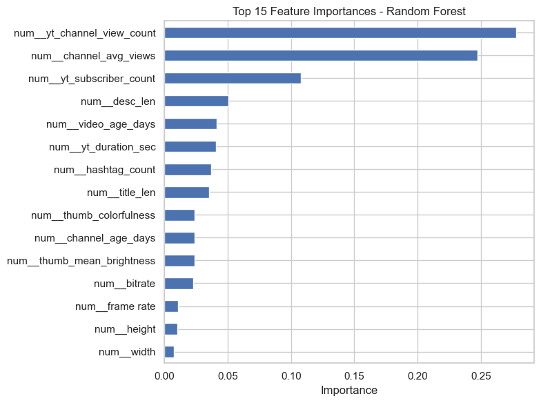

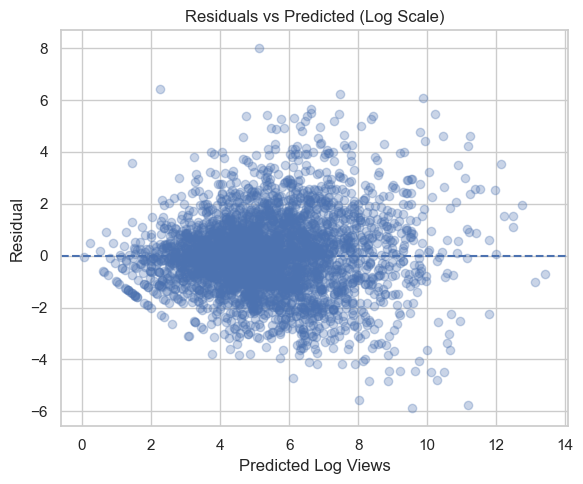

```python
import numpy as np
import pandas as pd
import matplotlib.pyplot as plt

from sklearn.pipeline import Pipeline
from sklearn.ensemble import RandomForestRegressor
from sklearn.model_selection import RandomizedSearchCV
from sklearn.metrics import mean_squared_error, mean_absolute_error, r2_score
from scipy.stats import randint

RANDOM_STATE = 42


rf_base_pipe = Pipeline([
    ('prep', preprocessor_unscaled),
    ('model', RandomForestRegressor(
        random_state=RANDOM_STATE,
        n_jobs=-1
    ))
])


param_dist = {
    'model__n_estimators': randint(300, 800),
    'model__max_depth': [None, 20, 40, 60],
    'model__min_samples_split': randint(2, 15),
    'model__min_samples_leaf': randint(1, 5),
    'model__max_features': ['sqrt', 'log2', 0.5]
}

rf_search = RandomizedSearchCV(
    estimator=rf_base_pipe,
    param_distributions=param_dist,
    n_iter=25,
    cv=5,
    scoring='neg_root_mean_squared_error',
    n_jobs=-1,
    random_state=RANDOM_STATE,
    verbose=1
)


rf_search.fit(X_train, y_train)

print("\nBest RF Parameters:")
print(rf_search.best_params_)

print("\nBest CV RMSE (log views):")
print(-rf_search.best_score_)


rf_best_pipe = rf_search.best_estimator_
rf_preds_log = rf_best_pipe.predict(X_test)

rf_rmse = np.sqrt(mean_squared_error(y_test, rf_preds_log))
rf_mae = mean_absolute_error(y_test, rf_preds_log)
rf_r2 = r2_score(y_test, rf_preds_log)

print("\nTest Metrics (log scale):")
print({
    'rmse_log_views': rf_rmse,
    'mae_log_views': rf_mae,
    'r2_log_views': rf_r2
})


actual_views = np.expm1(y_test)
pred_views = np.expm1(rf_preds_log)

rmse_views = np.sqrt(mean_squared_error(actual_views, pred_views))
mae_views = mean_absolute_error(actual_views, pred_views)

print("\nTest Metrics (actual view scale):")
print({
    'rmse_views': rmse_views,
    'mae_views': mae_views
})


results_df = pd.concat([
    results_df,
    pd.DataFrame([{
        'model': 'RandomForest_Tuned',
        'rmse_log_views': rf_rmse,
        'mae_log_views': rf_mae,
        'r2_log_views': rf_r2
    }])
], ignore_index=True).sort_values('rmse_log_views').reset_index(drop=True)

fitted_pipelines['RandomForest_Tuned'] = rf_best_pipe

print("\nUpdated Results Table:")
print(results_df)


print("\nTop 15 Feature Importances:")

feature_names = rf_best_pipe.named_steps['prep'].get_feature_names_out()
importances = rf_best_pipe.named_steps['model'].feature_importances_

feat_imp = pd.Series(importances, index=feature_names)
top_features = feat_imp.sort_values(ascending=False).head(15)

print(top_features)

plt.figure(figsize=(8,6))
top_features.sort_values().plot(kind='barh')
plt.title("Top 15 Feature Importances - Random Forest")
plt.xlabel("Importance")
plt.tight_layout()
plt.show()


residuals = y_test - rf_preds_log

plt.figure(figsize=(6,5))
plt.scatter(rf_preds_log, residuals, alpha=0.3)
plt.axhline(0, linestyle='--')
plt.title("Residuals vs Predicted (Log Scale)")
plt.xlabel("Predicted Log Views")
plt.ylabel("Residual")
plt.tight_layout()
plt.show()
```

### modeling_4_models.ipynb — Code Cell 9

```python
best_model_name = results_df.loc[0, 'model']
best_pipe = fitted_pipelines[best_model_name]
best_preds_log = best_pipe.predict(X_test)

compare = pd.DataFrame({
    'actual_views': np.expm1(y_test.values),
    'pred_views': np.expm1(best_preds_log)
})

compare['abs_error_views'] = (compare['actual_views'] - compare['pred_views']).abs()

print('Best model:', best_model_name)
print(compare[['actual_views', 'pred_views', 'abs_error_views']].describe())
```

```
Best model: RandomForest_Tuned
       actual_views     pred_views  abs_error_views
count  3.497000e+03    3497.000000     3.497000e+03
mean   2.202449e+04    2317.858110     2.097451e+04
std    2.835821e+05   18811.489902     2.785803e+05
min    0.000000e+00       0.061071     2.023379e-02
25%    4.000000e+01      61.531933     2.578750e+01
50%    1.550000e+02     187.966878     1.277418e+02
75%    9.160000e+02     650.245304     8.070398e+02
max    8.451637e+06  669248.214085     8.432087e+06
```

## Appendix — Chicago Style References (Author-Date)

Gaur, Manas, et al. 2024. “Transformer-Based Models for Social Media Text Classification.” In *Proceedings of the 2024 Conference on Empirical Methods in Natural Language Processing*, 1234–1245. Association for Computational Linguistics.

Hussain, Tasnim, et al. 2024. “The Impact of Subscriber Count and Upload Frequency on YouTube Engagement: A Tiered Analysis of Views, Likes, and Comments.” *Journal of Digital Media & Society* 12 (2): 45–67.

Koh, Joon Soo, and Cui Cheng. 2022. “Thumbnail Aesthetics and View-Through Rates: The Role of Brightness and Colorfulness in Click and Watch Behavior.” *Communication Research* 49 (5): 1–24.

Peng, Yuxin, and Wilma A. Bainbridge. 2026. “Memorability and Semantic Distinctiveness Predict Viral Potential of Images Independent of Emotional Valence.” *Cognitive Science* 50 (1): 1–18.